# PATH analysis of somatic evolution

```r
library(PATH)
library(expm)
library(ggplot2)
library(ggtree)
library(ggtreeExtra)
library(tidytree)
library(Matrix)
library(patchwork)

options(digits = 2)
```

### Introduction

In this vignette we demonstrate how to use PATH to measure categorical cell state phylogenetic correlations and how to infer cell state transition dynamics on phylogenies simulated as a *sampled somatic evolutionary process*. For a similar analysis using *idealized* phylogenies, or a more in depth introduction of how we model cell state transition dynamics, see this vignette. For more information, see our bioRxiv preprint.

### Somatic evolution

Here, we first randomly generate the transition rate matrix $Q$ using the PATH function `rQ()`, by specifying the number of cell states $n$ with the function’s first argument. Here we use this function to randomly generate a $3$-dimensional transition rate matrix and use `expm` to get the transition probability matrix.

#### Simulate

We then use `ran_tree_with_states()` to simulate a phylogeny using a sampled somatic evolutionary process, and set the number of sampled cells to be `N = 1000`, with a sampling rate of `rho = 10^-3`, meaning that the total simulated somatic population contains one million extant cells at the time of sampling.

```r
Q <- rQ(3, 0.1)
P <- expm(Q)
# Simulate phylogeny (phy1) with a sampled somatic evolutionary process
# using specified transition rate matrix (Q0), cell number (N), and
# cell sampling fraction (rho).
phy1 <- ran_tree_with_states(Q0 = Q, N = 1000, rho = 10^-3)
```

We can visualize this phylogeny and annotate the cells by their state.

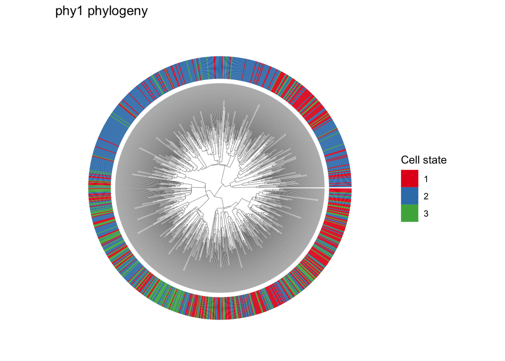